# Microplastics Intercalibration Study Data Analysis: Matrix Comparisons, Nile Red

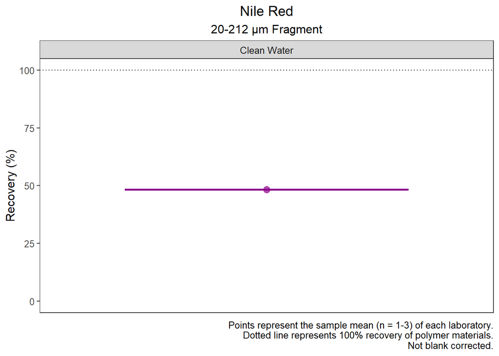

20-212 µm Fragment

| Matrix | Lab ID | Sample ID | Recovery |
| --- | --- | --- | --- |
| Clean Water | N | N_CW_1 | 39.37 |
| Clean Water | N | N_CW_2 | 51.18 |
| Clean Water | N | N_CW_3 | 54.46 |

20-212 µm Fragment

| Matrix | Lab ID | Mean (%) | Median (%) | SD (%) | Min (%) | Max (%) |
| --- | --- | --- | --- | --- | --- | --- |
| Clean Water | N | 48.34 | 51.18 | 7.94 | 39.37 | 54.46 |

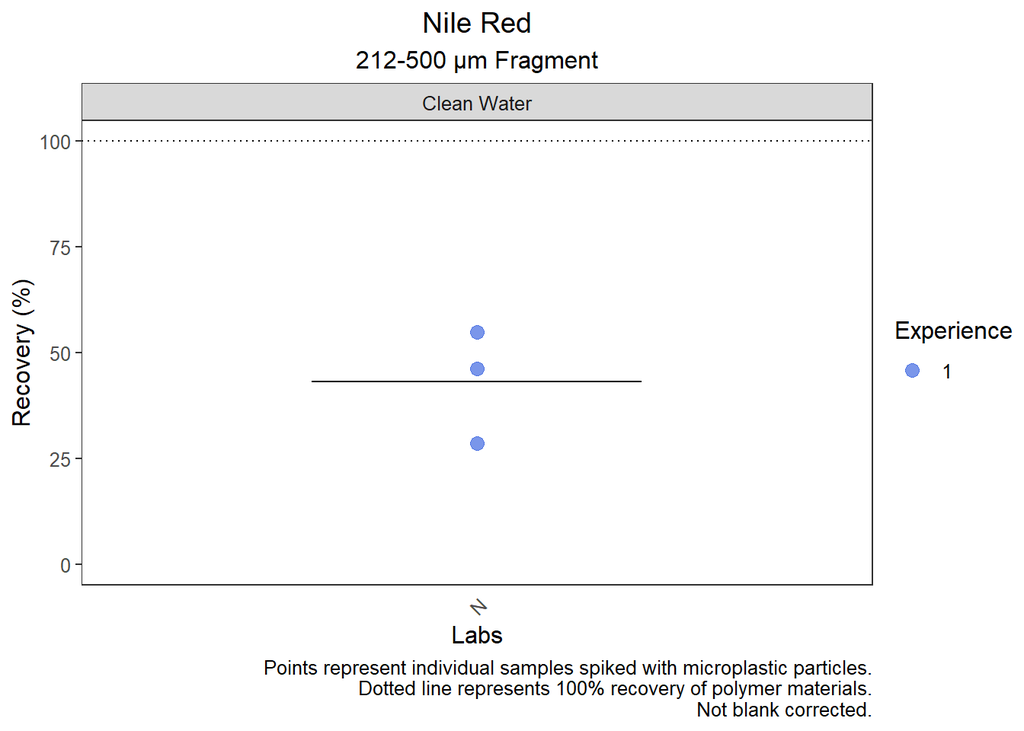

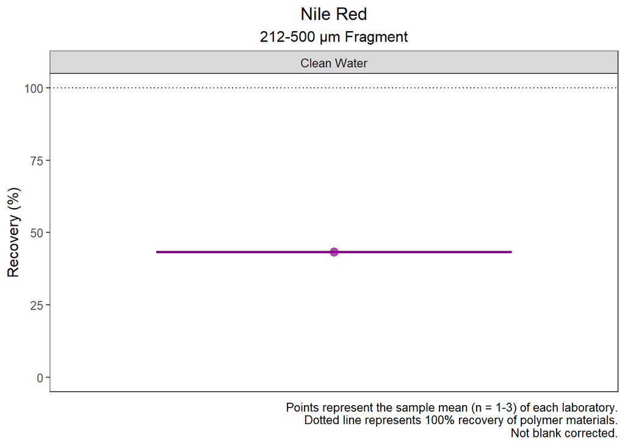

212-500 µm Fragment

| Matrix | Lab ID | Sample ID | Recovery |
| --- | --- | --- | --- |
| Clean Water | N | N_CW_1 | 46.15 |
| Clean Water | N | N_CW_2 | 28.57 |
| Clean Water | N | N_CW_3 | 54.95 |

212-500 µm Fragment

| Matrix | Lab ID | Mean (%) | Median (%) | SD (%) | Min (%) | Max (%) |
| --- | --- | --- | --- | --- | --- | --- |
| Clean Water | N | 43.22 | 46.15 | 13.43 | 28.57 | 54.95 |

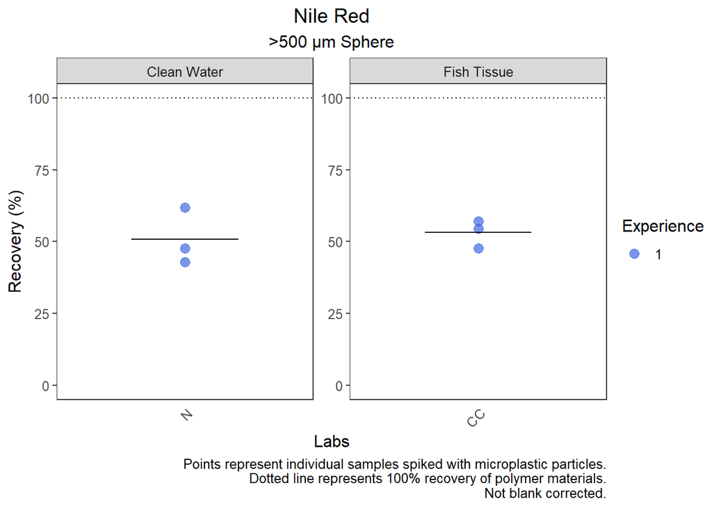

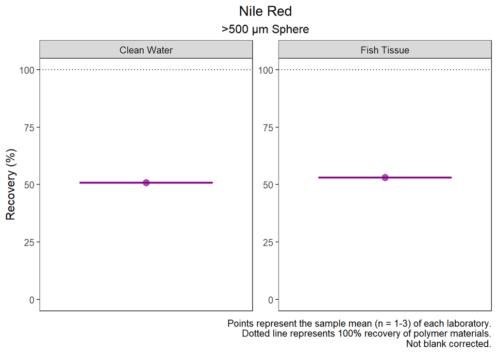

>500 µm Sphere

| Matrix | Lab ID | Sample ID | Recovery |
| --- | --- | --- | --- |
| Fish Tissue | CC | CC_FT_1 | 47.62 |
| Fish Tissue | CC | CC_FT_2 | 54.55 |
| Fish Tissue | CC | CC_FT_3 | 57.14 |
| Clean Water | N | N_CW_1 | 42.86 |
| Clean Water | N | N_CW_2 | 47.62 |
| Clean Water | N | N_CW_3 | 61.90 |

>500 µm Sphere

| Matrix | Lab ID | Mean (%) | Median (%) | SD (%) | Min (%) | Max (%) |
| --- | --- | --- | --- | --- | --- | --- |
| Fish Tissue | CC | 53.10 | 54.55 | 4.92 | 47.62 | 57.14 |
| Clean Water | N | 50.79 | 47.62 | 9.91 | 42.86 | 61.90 |

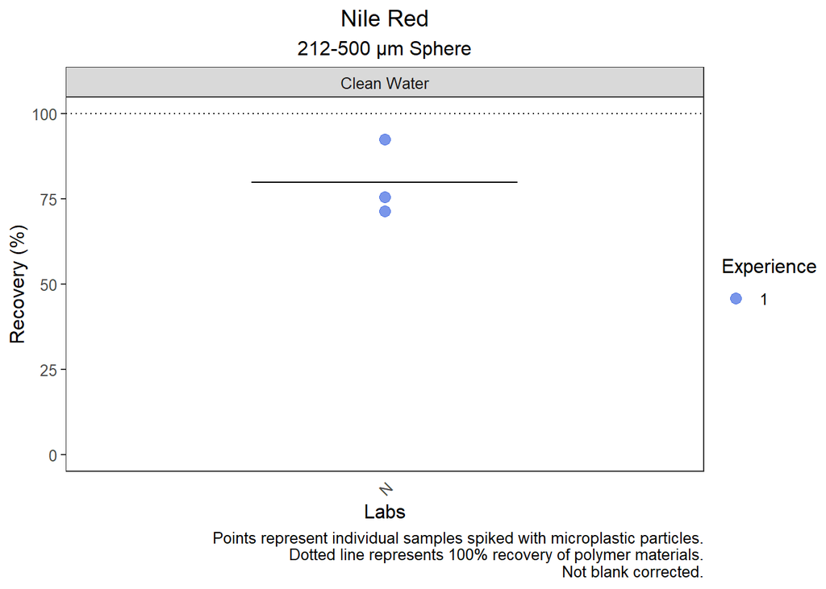

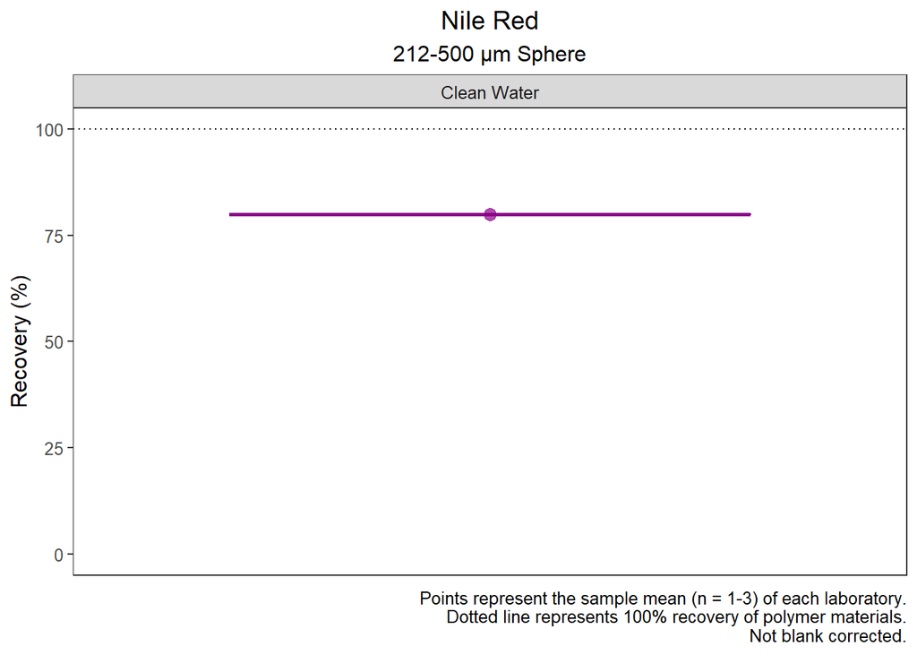

212-500 µm Sphere

| Matrix | Lab ID | Sample ID | Recovery |
| --- | --- | --- | --- |
| Clean Water | N | N_CW_1 | 92.44 |
| Clean Water | N | N_CW_2 | 71.43 |
| Clean Water | N | N_CW_3 | 75.63 |

212-500 µm Sphere

| Matrix | Lab ID | Mean (%) | Median (%) | SD (%) | Min (%) | Max (%) |
| --- | --- | --- | --- | --- | --- | --- |
| Clean Water | N | 79.83 | 75.63 | 11.12 | 71.43 | 92.44 |

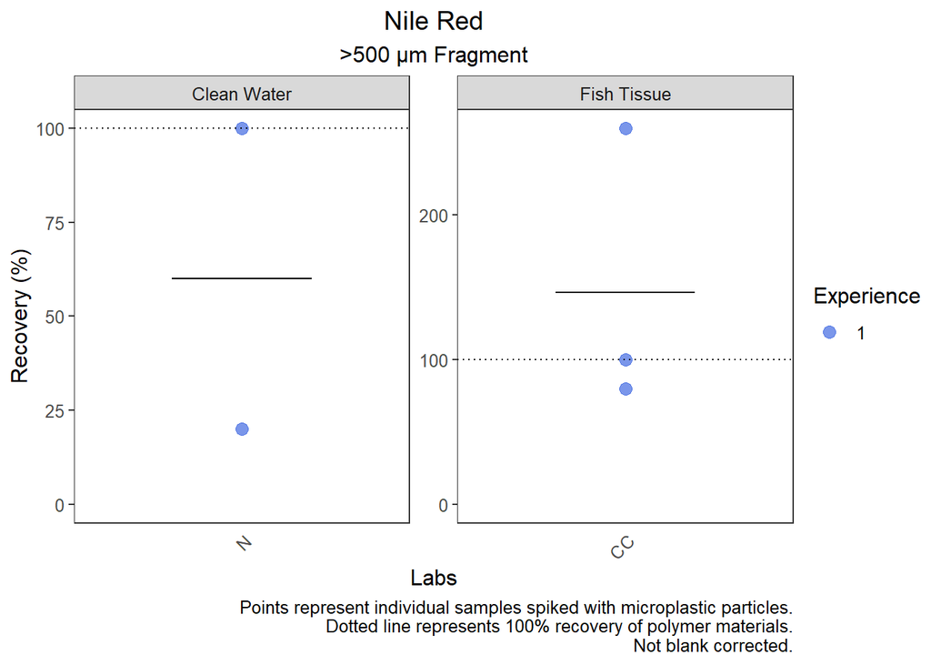

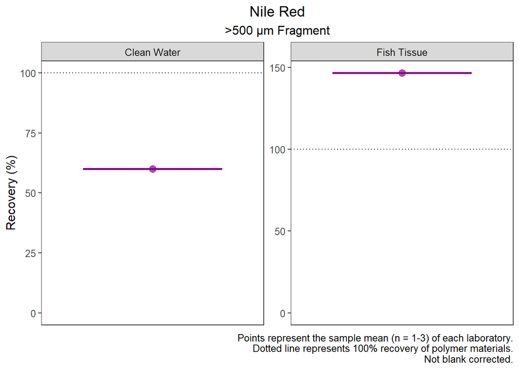

>500 µm Fragment

| Matrix | Lab ID | Sample ID | Recovery |
| --- | --- | --- | --- |
| Fish Tissue | CC | CC_FT_1 | 80 |
| Fish Tissue | CC | CC_FT_2 | 260 |
| Fish Tissue | CC | CC_FT_3 | 100 |
| Clean Water | N | N_CW_1 | 100 |
| Clean Water | N | N_CW_3 | 20 |

>500 µm Fragment

| Matrix | Lab ID | Mean (%) | Median (%) | SD (%) | Min (%) | Max (%) |
| --- | --- | --- | --- | --- | --- | --- |
| Fish Tissue | CC | 146.67 | 100 | 98.66 | 80 | 260 |
| Clean Water | N | 60.00 | 60 | 56.57 | 20 | 100 |

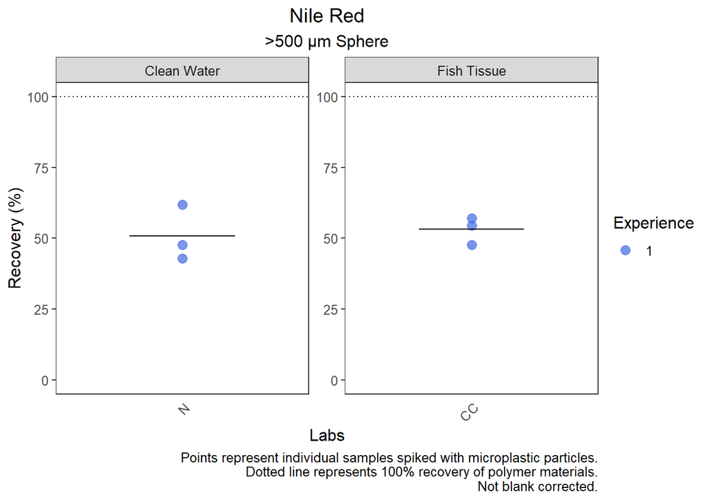

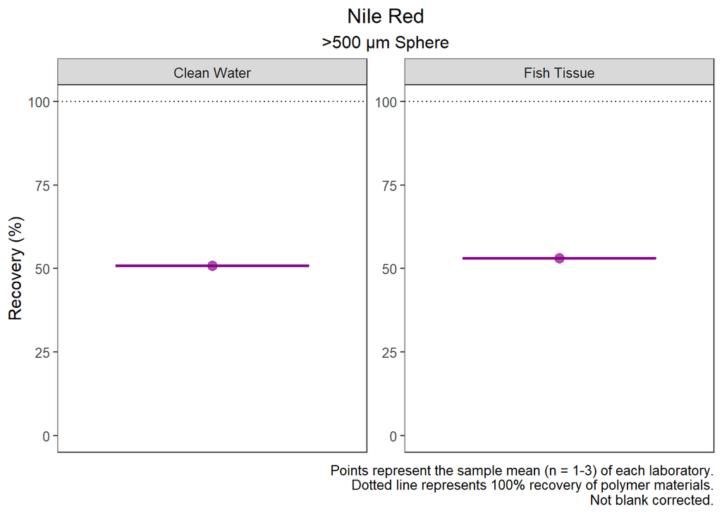

>500 µm Sphere

| Matrix | Lab ID | Sample ID | Recovery |
| --- | --- | --- | --- |
| Fish Tissue | CC | CC_FT_1 | 47.62 |
| Fish Tissue | CC | CC_FT_2 | 54.55 |
| Fish Tissue | CC | CC_FT_3 | 57.14 |
| Clean Water | N | N_CW_1 | 42.86 |
| Clean Water | N | N_CW_2 | 47.62 |
| Clean Water | N | N_CW_3 | 61.90 |

>500 µm Sphere

| Matrix | Lab ID | Mean (%) | Median (%) | SD (%) | Min (%) | Max (%) |
| --- | --- | --- | --- | --- | --- | --- |
| Fish Tissue | CC | 53.10 | 54.55 | 4.92 | 47.62 | 57.14 |
| Clean Water | N | 50.79 | 47.62 | 9.91 | 42.86 | 61.90 |

Nile Red: Recovery, All Spiked Particles. Summary statistics across all laboratories. Not blank corrected.

[output not shown]

# 4 Clean Water, Fish Tissue, Sediment & Dirty Water Comparisons > 212 µm

## 4.1 Recovery

The following plots display the recovery (reported count/spiked count (%)) obtained from microscopy with nile red. **Reported particle characteristics must match expected particle characteristics of the spiking materials to count towards recovery estimations.** For example, the colors of polymer spiking materials are defined as white, orange, blue, clear and green. Colors outside of these definitions are not included in this section (see Counts).

The dotted line is at 100% and the grey area represents the mean RSD for each given category. The data are **not** blank corrected.

Recovery in this section is estimated based on a single particle characteristic. For example, if the sample was spiked with 10 green particles and 8 green particles were recovered, recovery is estimated as 80% regardless of whether or not the shape or size fraction also matches the spiking material. More restrictive recovery analysis are reported later on in this document.

### 4.1.1 Total

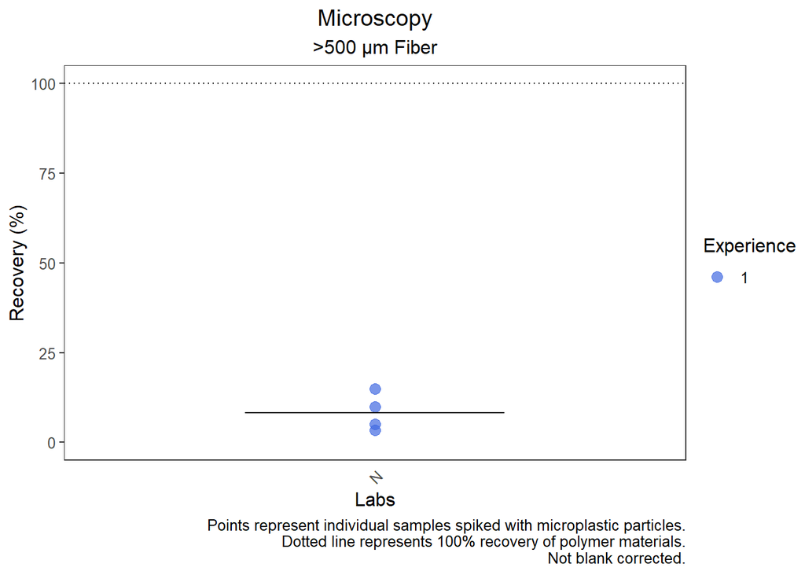

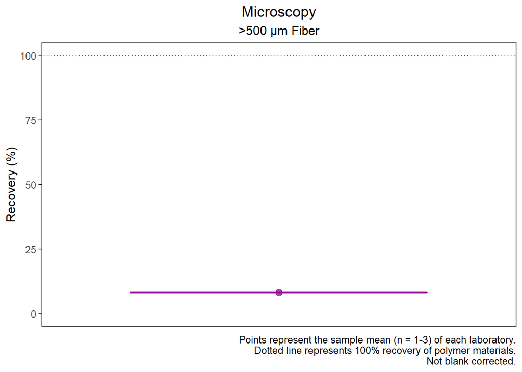

>500 µm Fiber

| Lab ID | Sample ID | Recovery |
| --- | --- | --- |
| N | N_CW_1 | 15.00 |
| N | N_CW_1 | 5.00 |
| N | N_CW_3 | 10.00 |
| N | N_CW_3 | 3.33 |

>500 µm Fiber

| Lab ID | Mean (%) | Median (%) | SD (%) | Min (%) | Max (%) |
| --- | --- | --- | --- | --- | --- |
| N | 8.33 | 7.5 | 5.27 | 3.33 | 15 |

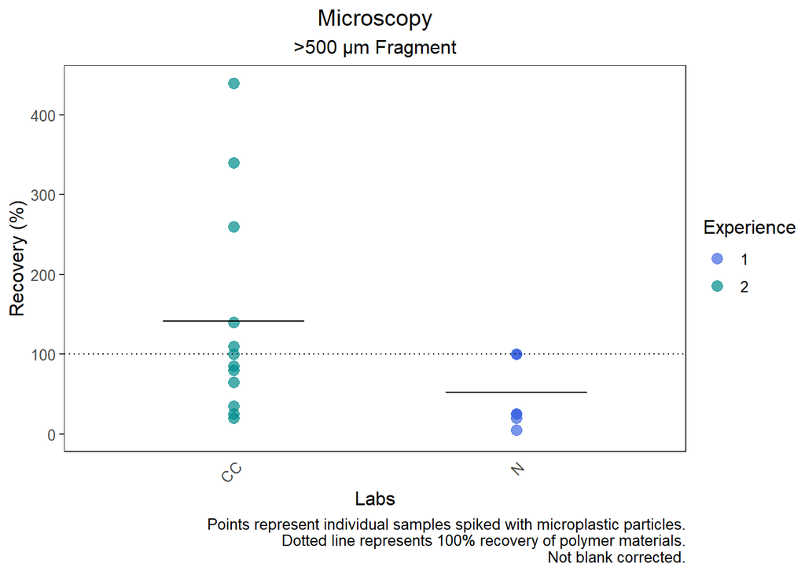

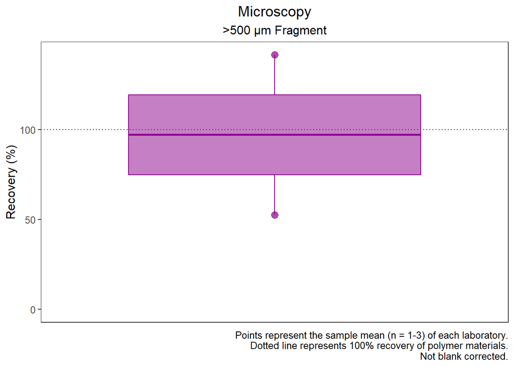

>500 µm Fragment

| Lab ID | Sample ID | Recovery |
| --- | --- | --- |
| CC | CC_DW_1 | 140 |
| CC | CC_DW_1 | 35 |
| CC | CC_DW_2 | 440 |
| CC | CC_DW_2 | 110 |
| CC | CC_DW_3 | 340 |
| CC | CC_DW_3 | 85 |
| CC | CC_FT_1 | 80 |
| CC | CC_FT_1 | 20 |
| CC | CC_FT_2 | 260 |
| CC | CC_FT_2 | 65 |
| CC | CC_FT_3 | 100 |
| CC | CC_FT_3 | 25 |
| N | N_CW_1 | 100 |
| N | N_CW_1 | 25 |
| N | N_CW_3 | 20 |
| N | N_CW_3 | 5 |
| N | N_DW_1 | 100 |
| N | N_DW_1 | 25 |
| N | N_DW_2 | 100 |
| N | N_DW_2 | 25 |
| N | N_DW_3 | 100 |
| N | N_DW_3 | 25 |

>500 µm Fragment

| Lab ID | Mean (%) | Median (%) | SD (%) | Min (%) | Max (%) |
| --- | --- | --- | --- | --- | --- |
| CC | 141.67 | 92.5 | 134.09 | 20 | 440 |
| N | 52.50 | 25.0 | 41.32 | 5 | 100 |

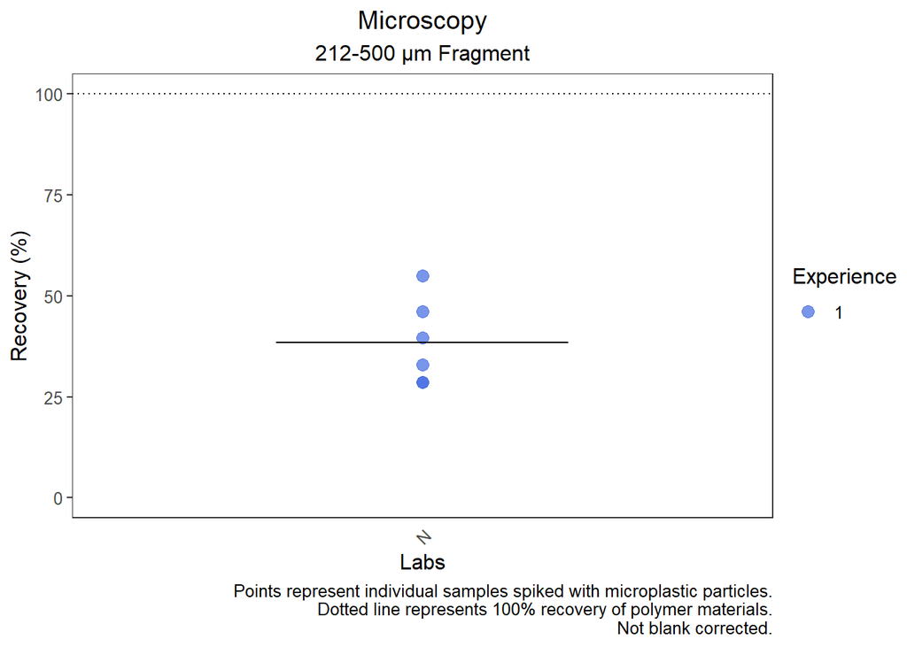

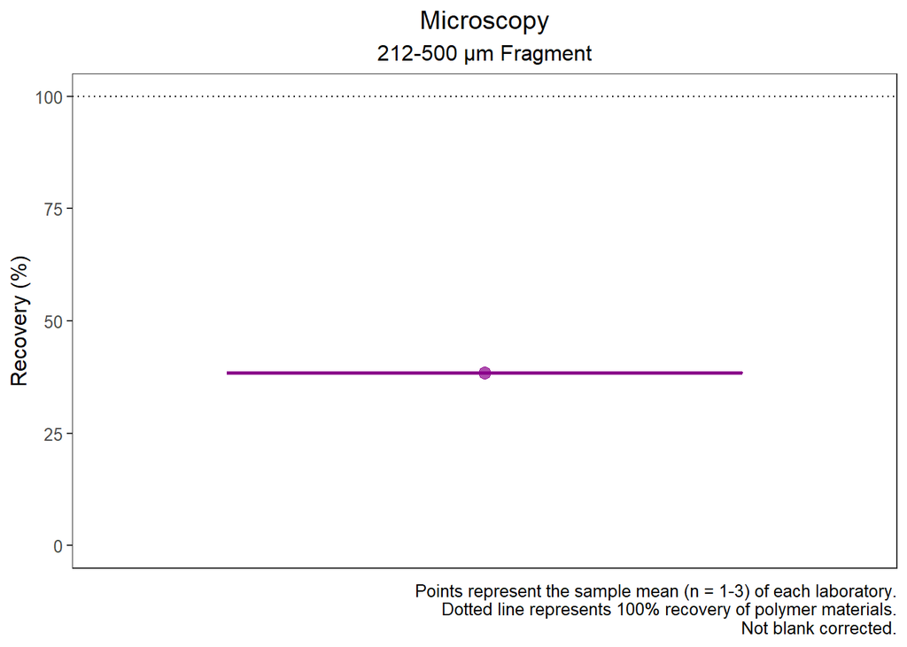

212-500 µm Fragment

| Lab ID | Sample ID | Recovery |
| --- | --- | --- |
| N | N_CW_1 | 46.15 |
| N | N_CW_2 | 28.57 |
| N | N_CW_3 | 54.95 |
| N | N_DW_1 | 32.97 |
| N | N_DW_2 | 28.57 |
| N | N_DW_3 | 39.56 |

212-500 µm Fragment

| Lab ID | Mean (%) | Median (%) | SD (%) | Min (%) | Max (%) |
| --- | --- | --- | --- | --- | --- |
| N | 38.46 | 36.26 | 10.56 | 28.57 | 54.95 |

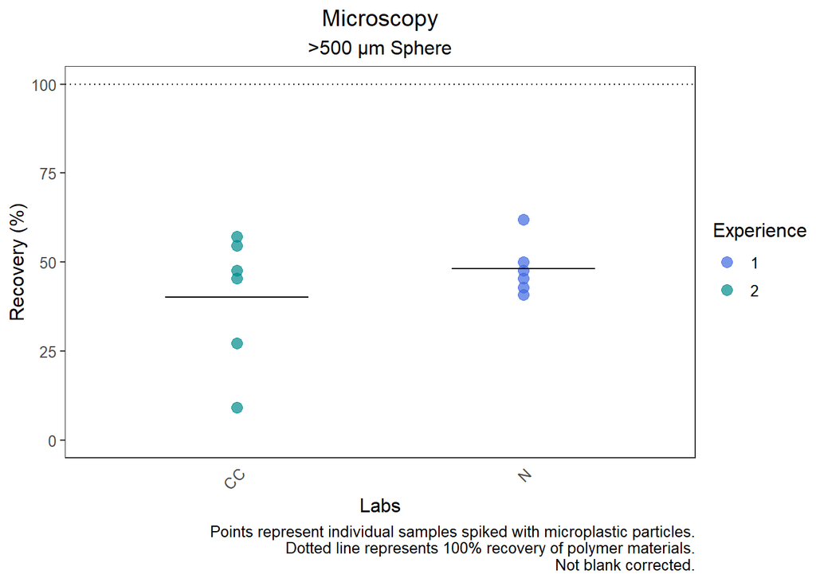

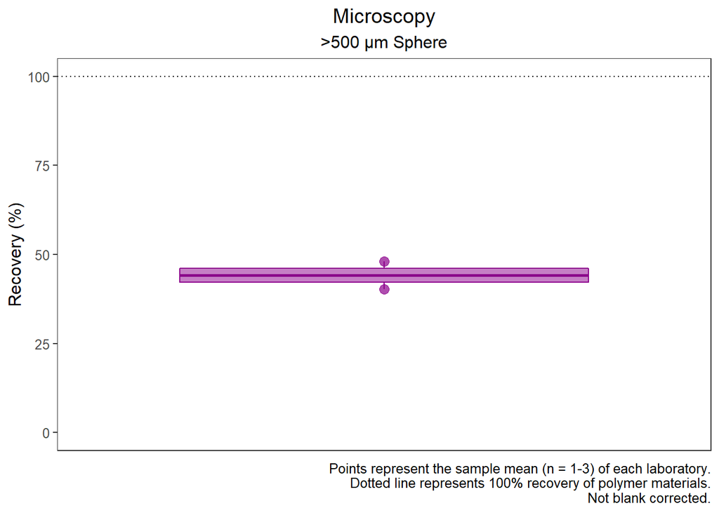

>500 µm Sphere

| Lab ID | Sample ID | Recovery |
| --- | --- | --- |
| CC | CC_DW_1 | 9.09 |
| CC | CC_DW_2 | 27.27 |
| CC | CC_DW_3 | 45.45 |
| CC | CC_FT_1 | 47.62 |
| CC | CC_FT_2 | 54.55 |
| CC | CC_FT_3 | 57.14 |
| N | N_CW_1 | 42.86 |
| N | N_CW_2 | 47.62 |
| N | N_CW_3 | 61.90 |
| N | N_DW_1 | 40.91 |
| N | N_DW_2 | 45.45 |
| N | N_DW_3 | 50.00 |

>500 µm Sphere

| Lab ID | Mean (%) | Median (%) | SD (%) | Min (%) | Max (%) |
| --- | --- | --- | --- | --- | --- |
| CC | 40.19 | 46.54 | 18.50 | 9.09 | 57.14 |
| N | 48.12 | 46.54 | 7.49 | 40.91 | 61.90 |

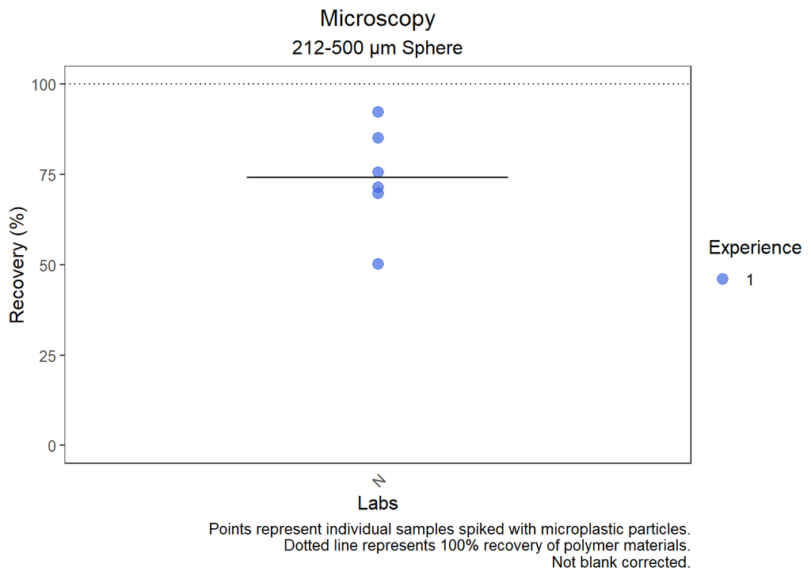

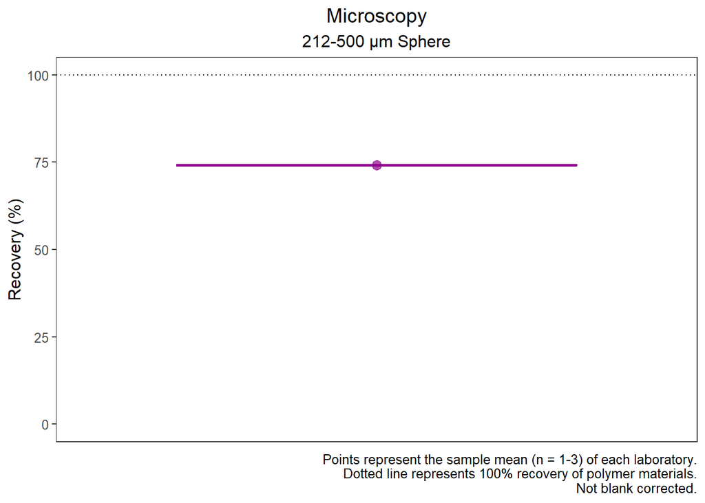

212-500 µm Sphere

| Lab ID | Sample ID | Recovery |
| --- | --- | --- |
| N | N_CW_1 | 92.44 |
| N | N_CW_2 | 71.43 |
| N | N_CW_3 | 75.63 |
| N | N_DW_1 | 50.39 |
| N | N_DW_2 | 85.27 |
| N | N_DW_3 | 69.77 |

212-500 µm Sphere

| Lab ID | Mean (%) | Median (%) | SD (%) | Min (%) | Max (%) |
| --- | --- | --- | --- | --- | --- |
| N | 74.15 | 73.53 | 14.5 | 50.39 | 92.44 |

### 4.1.2 Size Fraction

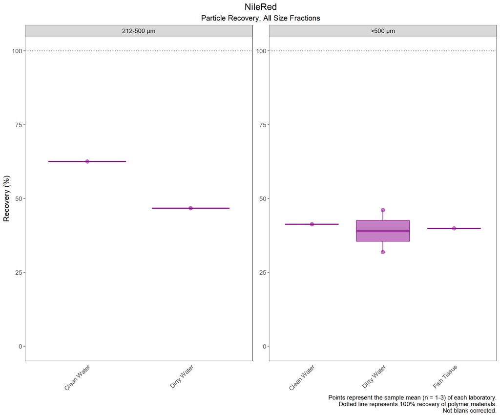

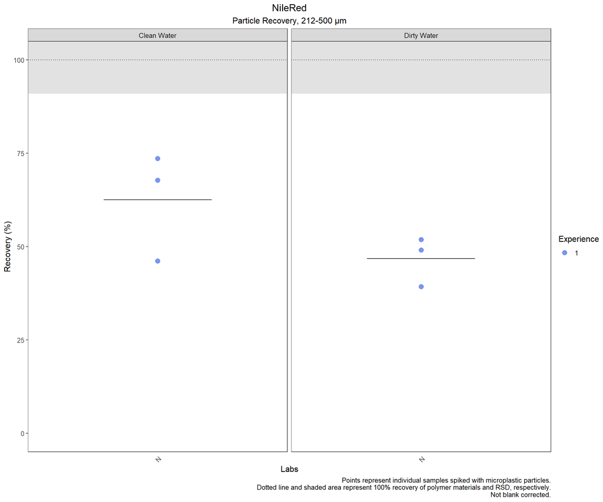

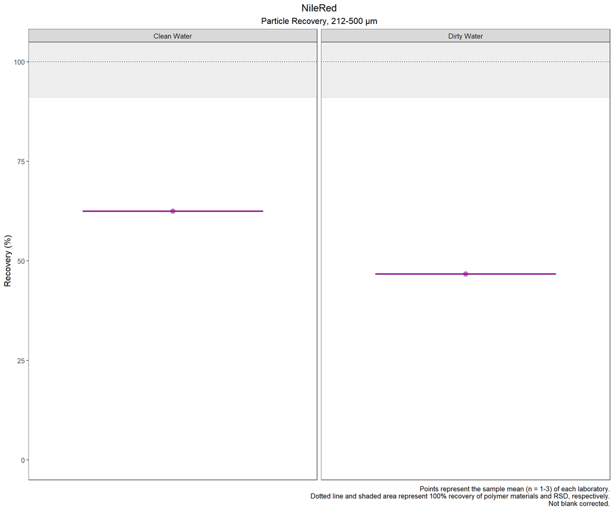

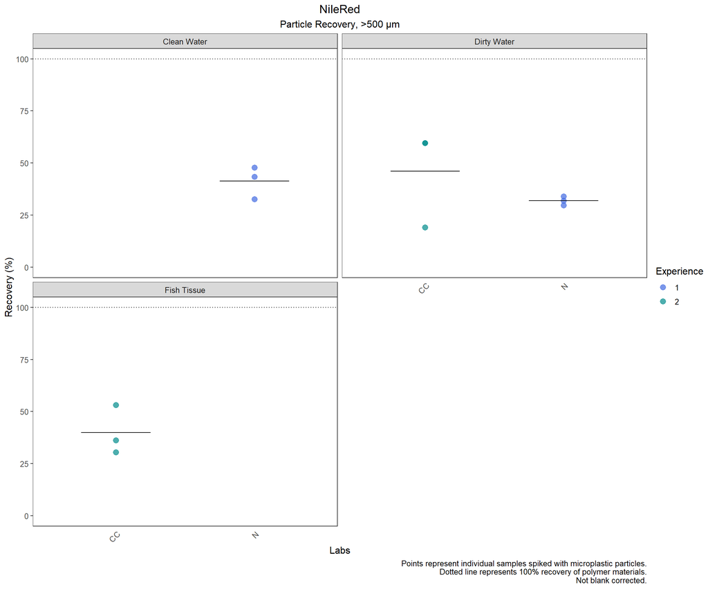

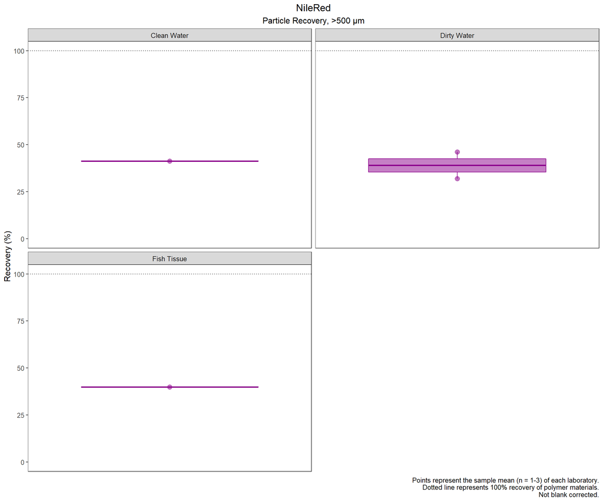

NileRed: Total Particle Recovery by Size Fraction. Summary statistics by sample (n = 1-3 samples). Not blank corrected.

| Matrix | Lab ID | Sample ID | Size Fraction | Recovery |
| --- | --- | --- | --- | --- |
| Clean Water | N | N_CW_1 | >500 µm | 47.83 |
| Clean Water | N | N_CW_1 | 212-500 µm | 67.82 |
| Clean Water | N | N_CW_2 | >500 µm | 32.61 |
| Clean Water | N | N_CW_2 | 212-500 µm | 46.18 |
| Clean Water | N | N_CW_3 | >500 µm | 43.48 |
| Clean Water | N | N_CW_3 | 212-500 µm | 73.59 |
| Dirty Water | CC | CC_DW_1 | >500 µm | 19.15 |
| Dirty Water | CC | CC_DW_2 | >500 µm | 59.57 |
| Dirty Water | CC | CC_DW_3 | >500 µm | 59.57 |
| Dirty Water | N | N_DW_1 | >500 µm | 29.79 |
| Dirty Water | N | N_DW_1 | 212-500 µm | 39.27 |
| Dirty Water | N | N_DW_2 | >500 µm | 31.91 |
| Dirty Water | N | N_DW_2 | 212-500 µm | 49.09 |
| Dirty Water | N | N_DW_3 | >500 µm | 34.04 |
| Dirty Water | N | N_DW_3 | 212-500 µm | 51.89 |
| Fish Tissue | CC | CC_FT_1 | >500 µm | 30.43 |
| Fish Tissue | CC | CC_FT_2 | >500 µm | 53.19 |
| Fish Tissue | CC | CC_FT_3 | >500 µm | 36.17 |

NileRed: Total Particle Recovery by Size Fraction. Summary statistics by laboratory (n = 1-3 samples). Not blank corrected.

| Matrix | Lab ID | Size Fraction | Mean (%) | Median (%) | SD (%) | Min (%) | Max (%) |
| --- | --- | --- | --- | --- | --- | --- | --- |
| Dirty Water | CC | >500 µm | 46.10 | 59.57 | 23.34 | 19.15 | 59.57 |
| Fish Tissue | CC | >500 µm | 39.93 | 36.17 | 11.84 | 30.43 | 53.19 |
| Clean Water | N | >500 µm | 41.30 | 43.48 | 7.84 | 32.61 | 47.83 |
| Dirty Water | N | >500 µm | 31.91 | 31.91 | 2.13 | 29.79 | 34.04 |
| Clean Water | N | 212-500 µm | 62.53 | 67.82 | 14.45 | 46.18 | 73.59 |
| Dirty Water | N | 212-500 µm | 46.75 | 49.09 | 6.63 | 39.27 | 51.89 |

NileRed: Total Particle Recovery by Size Fraction. Summary statistics across all laboratories. Not blank corrected.

| Matrix | Size Fraction | Global Mean (%) | Median (%) | SD (%) | Min (%) | Max (%) |
| --- | --- | --- | --- | --- | --- | --- |
| Clean Water | >500 µm | 41.30 | 41.30 | NA | 41.30 | 41.30 |
| Clean Water | 212-500 µm | 62.53 | 62.53 | NA | 62.53 | 62.53 |
| Dirty Water | >500 µm | 39.01 | 39.01 | 10.03 | 31.91 | 46.10 |
| Dirty Water | 212-500 µm | 46.75 | 46.75 | NA | 46.75 | 46.75 |
| Fish Tissue | >500 µm | 39.93 | 39.93 | NA | 39.93 | 39.93 |

### 4.1.3 Morphology

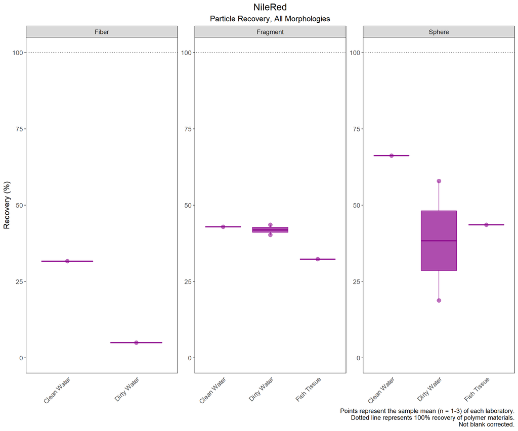

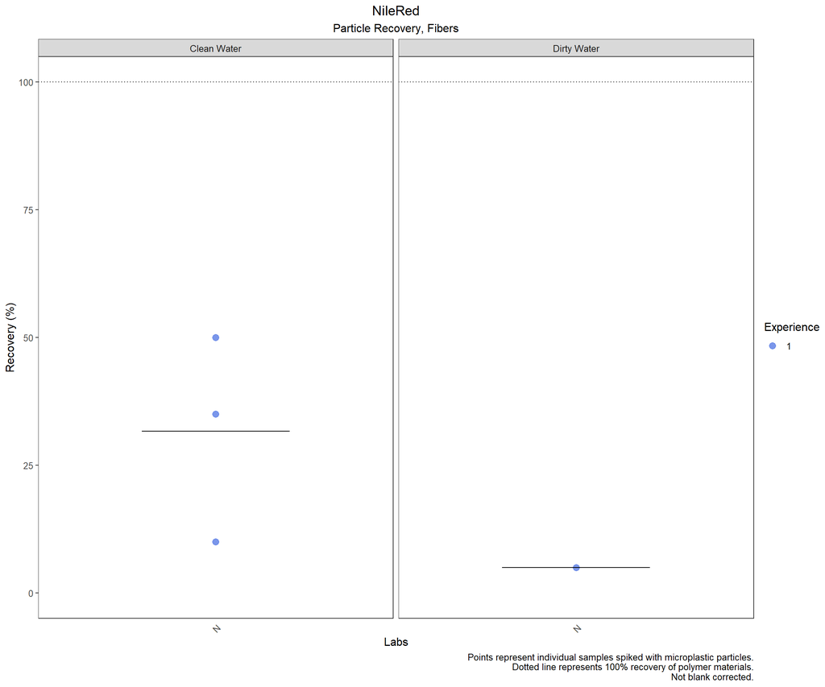

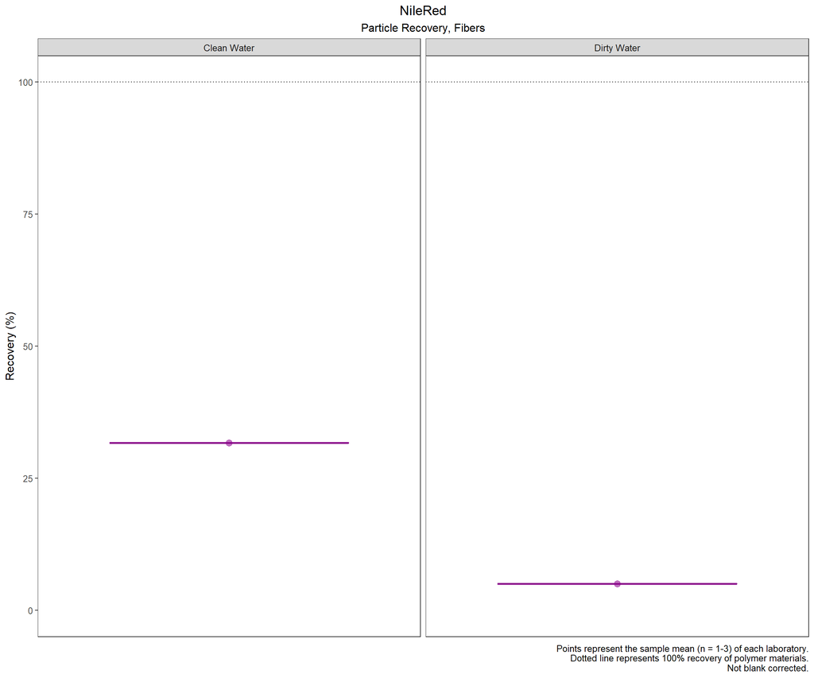

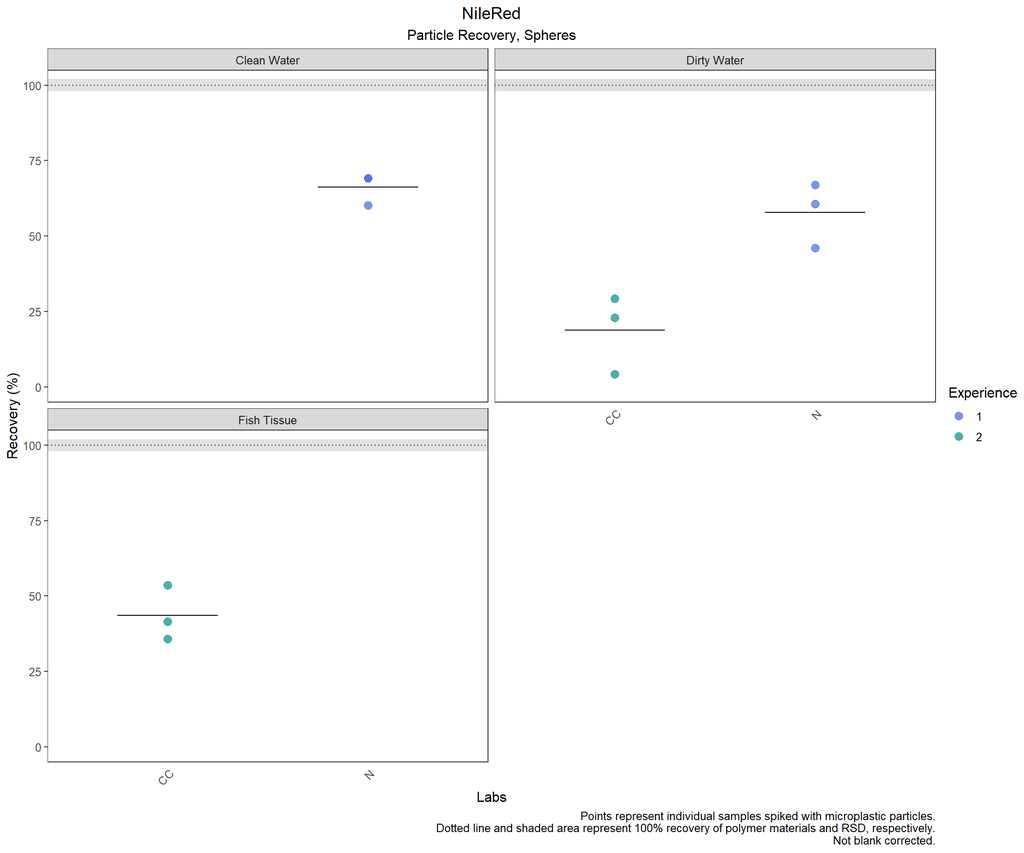